# Tema 6: Grafos y árboles soporte

## Matriz de adyacencia (Digrafo)

**Definición: Matriz de adyacencia orientada**

Dado un digrafo $G = (V, U)$, la matriz $B \in \mathbb{R}^{n \times n}$ es asimétrica:
$$\small
b_{ik} = \begin{cases}
1 & \text{si } (i, k) \in U \\
0 & \text{en otro caso}
\end{cases}$$

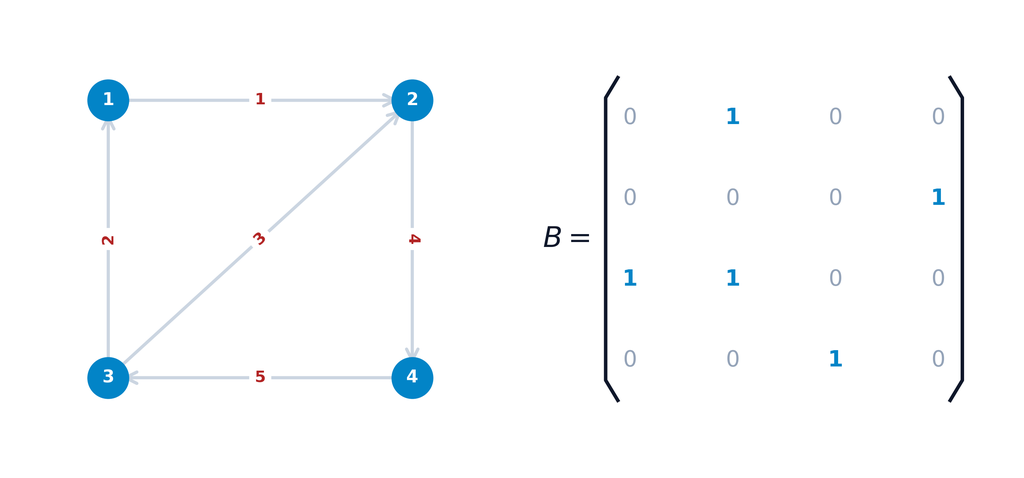

- **Conteo de caminos**: El elemento $(B^p)_{ik}$ de la potencia $B^p$ indica el número exacto de caminos de longitud $p$ entre los nodos $i$ y $k$.

## Motivación: Redes dispersas y almacenamiento

- **Inconveniente de matrices densas**: En redes dispersas (donde el número de arcos es mucho menor que el cuadrado de nodos, $m \ll n^2$), las matrices de adyacencia o incidencia almacenan más del $99\%$ de entradas nulas (ceros).
- **Almacenamiento lineal eficiente**: Para optimizar el uso de memoria y la velocidad de cómputo, las matrices se sustituyen por dos vectores unidimensionales de dimensión reducida:
  - **Vector $\beta$** (dimensión $m$): Almacena los nodos de destino.
  - **Vector $\alpha$** (dimensión $n+1$): Almacena los punteros de inicio.

## Esquema de punteros ($\alpha, \beta$) en digrafos

- **Vector $\beta$** (dimensión $m$): Contiene los nodos de destino $j$ de todos los arcos $(i, j) \in U$, agrupados en orden lexicográfico según el nodo origen $i$.
- **Vector $\alpha$** (dimensión $n+1$): Punteros que indican la posición en $\beta$ donde comienzan los arcos salientes de cada nodo $i$.
  - **Condición de cierre**: $\alpha(n+1) = m + 1$.

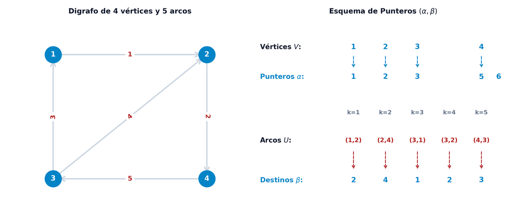

## Ejemplo: Evaluación de vectores ($\alpha, \beta$) en redes

- **Recurrencia regresiva para $\alpha$**:
  $$\alpha(k) = \alpha(k+1) - d^+(k)$$
  con la condición inicial $\alpha(n+1) = m + 1$.
- **Evaluación en la red ($n=6, m=10$)**:
  - Condición inicial: $\alpha(7) = 10 + 1 = 11$.
  - Vector de destinos $\beta \in \mathbb{R}^{10}$.
  - Vector de punteros resultante:
    $$\alpha = (1, 4, 5, 7, 10, 11, 11)$$

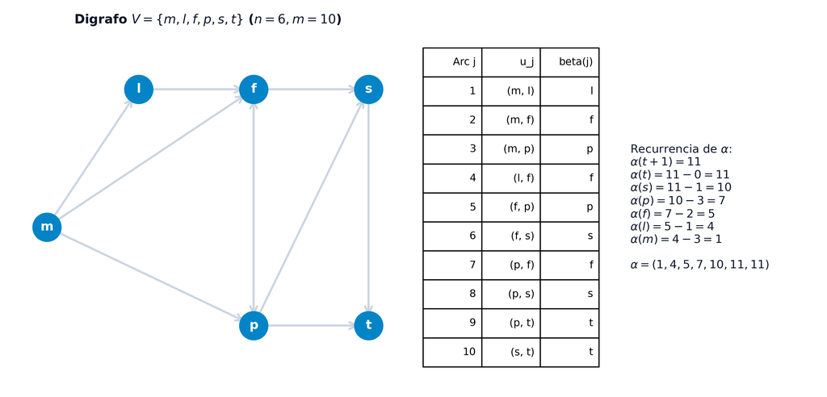

## Representación vectorial en grafos no dirigidos

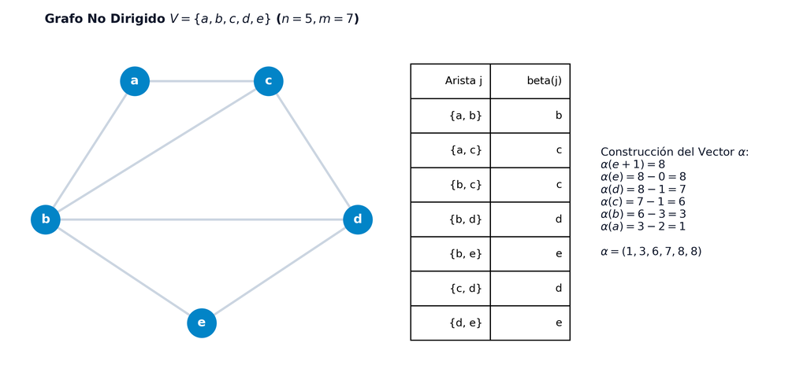

## Listas de adyacencia en digrafos

- **Estructura dinámica**: Arreglo de punteros $\text{Adj}[i]$ donde cada nodo $i$ encadena la lista de sus nodos sucesores $\Gamma^+(i)$.
- **Propiedades computacionales**:
  - **Memoria óptima**: Complejidad espacial $O(n + m)$.
  - **Eficiencia dinámica**: Permite insertar y eliminar arcos de forma dinámica con tiempo $O(1)$.

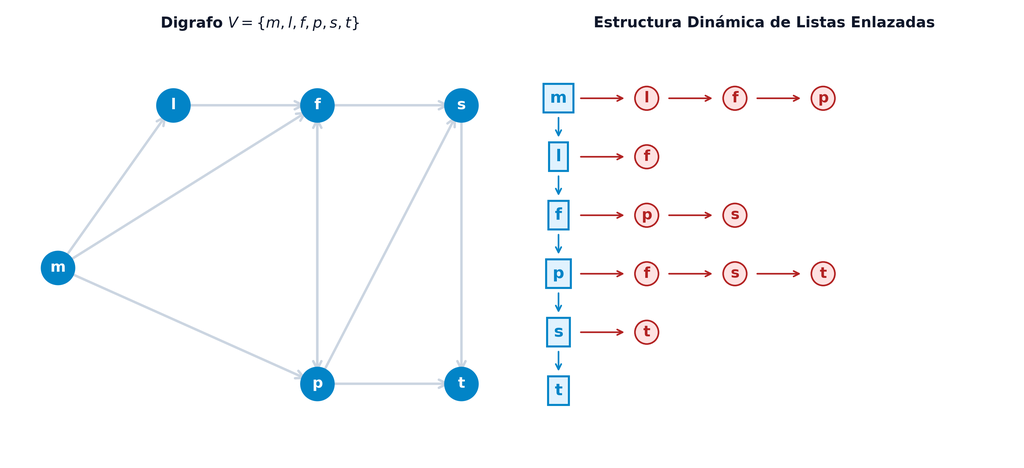

## Listas de adyacencia en grafos no dirigidos

- **Listas enlazadas recíprocas**: En grafos no dirigidos $G = (V, E)$, cada arista no dirigida $\{u, v\}$ genera dos entradas recíprocas en las estructuras enlazadas:
  - El nodo $v$ se añade a la lista $\text{Adj}[u]$.
  - Simétricamente, el nodo $u$ se incorpora a la lista $\text{Adj}[v]$.
- **Ejemplo sobre $V = \{a, b, c, d, e\}$**: Representación en red de 5 vértices con conexiones simétricas bidireccionales.

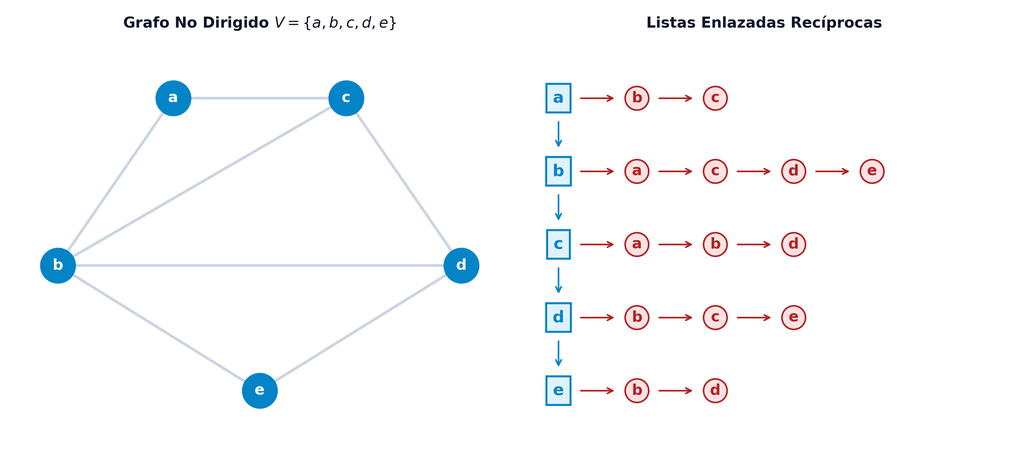

# Estructura matemática de los árboles

## Definición de Árbol y Bosque

**Definición: Árbol y bosque**

- **Árbol**: Grafo no dirigido **conexo y acíclico**.
- **Bosque**: Grafo acíclico cuyas componentes conexas son árboles.
- **Matriz de incidencia**: Sus columnas son linealmente independientes.

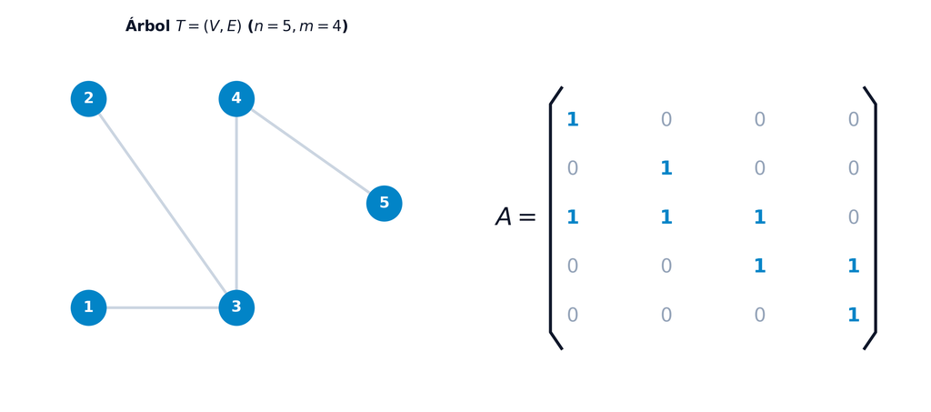

## Teorema: Caracterizaciones de un árbol (Parte 1)

**Caracterizaciones equivalentes (1 a 3)**

Dado un grafo no dirigido $G = (V, E)$ con $n$ vértices y $m$ aristas, las siguientes propiedades son **equivalentes**:

1. **Conexo y acíclico**: $G$ es un grafo conexo sin ningún ciclo.
2. **Acíclico maximal**: $G$ es acíclico y al añadir una nueva arista entre cualquier par de vértices no adyacentes se crea **exactamente un ciclo**.
3. **Unicidad de cadenas**: Existe una **única cadena simple** entre todo par de vértices de $G$.

## Teorema: Caracterizaciones de un árbol (Parte 2)

**Caracterizaciones equivalentes (4 a 6)**

4. **Mínimamente conexo**: $G$ es conexo y la eliminación de cualquier arista **lo desconecta** ($G \setminus \{e\}$ no es conexo).
5. **Acíclico con $m = n - 1$ aristas**: $G$ es acíclico y el número de aristas satisface exactamente $m = n - 1$.
6. **Conexo con $m = n - 1$ aristas**: $G$ es conexo y el número de aristas satisface exactamente $m = n - 1$.

## Fórmula de Cayley y Vector de padres

- **Fórmula de Cayley (1889)**: El número de árboles soporte sobre $n$ vértices es:
  $$T(n) = n^{n-2}$$
- **Representación por Vector de Padres $p(v)$**: Al elegir una raíz $x_0$, $p(v)$ almacena el antecesor directo en la cadena desde $x_0$. Ocupa solo $n$ enteros.

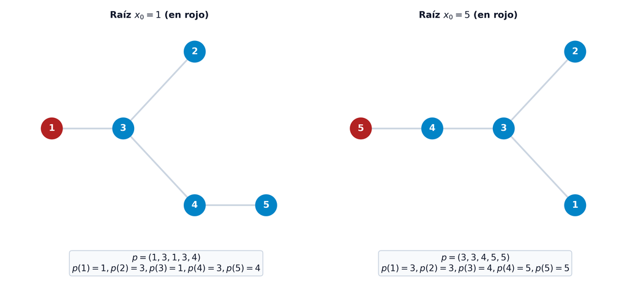

- Izquierda: Raíz $x_0 = 1 \implies p = (1, 3, 1, 3, 4)$.
- Derecha: Raíz $x_0 = 5 \implies p = (3, 3, 4, 5, 5)$.

# Árbol soporte de mínimo peso (MST)

## Redes valoradas: Definición y Notación

**Definición: Red valorada y peso de aristas**

Una **red valorada** es un par $(G, \mathbf{d})$, donde $G = (V, E)$ o $G = (V, U)$ es un grafo o digrafo y $\mathbf{d} \in \mathbb{R}^m$ es un vector cuyas componentes asignan un coste o peso $d(e) = d_e$ a cada arista $e \in E$ (o $c_{ij}$ a cada arco $(i, j) \in U$).

## Formulación Primal del Problema del MST

**Formulación Primal del Problema del MST**

Dada una red valorada conexa no dirigida $(G, \mathbf{d})$ con $G = (V, E)$ y pesos $\{d_e : e \in E\}$, el **Problema del Árbol Soporte de Mínimo Peso** (*Minimum Spanning Tree*, MST) busca un subconjunto de aristas $T \subset E$ tal que $H = (V, T)$ sea un árbol soporte que minimice el peso acumulado:
$$\begin{aligned}
\min_{T \subset E} \quad & d(T) = \sum_{e \in T} d_e \\
\text{sujeto a} \quad & H = (V, T) \text{ es un árbol soporte de } G
\end{aligned}$$

## Ejemplo: Espacio de soluciones del MST

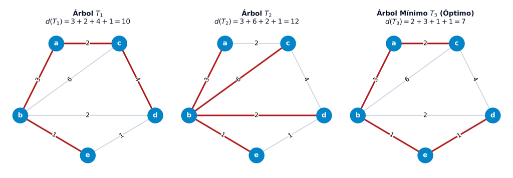

- Comparación de tres árboles soporte candidatos sobre una red no dirigida de 5 vértices $V = \{a, b, c, d, e\}$.

## Ejemplo: Evaluación de coste en árboles candidatos

Evaluación de pesos acumulados sobre la red de 5 vértices:

- **Candidato $T_1$** ($\{a,b\}, \{a,c\}, \{c,d\}, \{b,e\}$):
  $$d(T_1) = 3 + 2 + 4 + 1 = 10$$
- **Candidato $T_2$** ($\{a,b\}, \{b,c\}, \{b,d\}, \{b,e\}$):
  $$d(T_2) = 3 + 6 + 2 + 1 = 12$$
- **Árbol Mínimo $T_3$ (Óptimo)** ($\{a,c\}, \{a,b\}, \{b,e\}, \{e,d\}$):
  $$d(T_3) = 2 + 3 + 1 + 1 = 7$$

## Teorema: Propiedad del Corte (Cut Property)

**Teorema: Propiedad del Corte (Cut Property)**

Sea $(G, \mathbf{d})$ una red valorada conexa no dirigida. Dado cualquier subconjunto propio de vértices $S \subset V$, si la arista $e^* = \{u, v\}$ con $u \in S, v \in V \setminus S$ es la arista de **peso estrictamente mínimo** que cruza el corte $w(S)$, entonces la arista $e^*$ **pertenece obligatoriamente a todo Árbol Soporte de Mínimo Peso** de $G$.

- **Fundamento algorítmico**: La propiedad del corte permite tomar decisiones locales óptimas (*golosas*) sin necesidad de evaluar la cantidad exponencial de árboles soporte ($T(n) = n^{n-2}$).

## Algoritmo de Kruskal: Estrategia Golosa

**Filosofía del Algoritmo de Kruskal (1956)**

- Propuesto por Joseph Kruskal (1956), adopta una **estrategia golosa (*greedy*) global** centrada en el ordenamiento de las aristas.
- Examina secuencialmente las aristas de la red en orden creciente de peso e incorpora a la solución parcial la arista disponible de menor coste, siempre que **no genere ningún ciclo** con las aristas previamente seleccionadas.
- **Bosque disjunto parcial**: En las fases intermedias, las aristas en $T$ no forman una estructura conexa continua, sino un **bosque parcial de árboles disjuntos** que se fusionan progresivamente hasta alcanzar $|T| = n - 1$ aristas.

## Esquema de Kruskal: Inicialización y Selección

Dada una red no dirigida valorada $G = (V, E, \mathbf{d})$ con $n = |V| > 1$ vértices:

- **Paso 0 (Inicialización)**:
  - Definir $T = \emptyset$ y conjunto de aristas disponibles $A \leftarrow E$.
- **Paso 1 (Bucle de Selección Golosa)**:
  - Mientras $|T| < n - 1$ y $A \neq \emptyset$:
    1. Identificar la arista $e \in A$ de menor peso global.
    2. Actualizar el conjunto de disponibles: $A \leftarrow A \setminus \{e\}$.
    3. Si el subconjunto $T \cup \{e\}$ **no contiene ningún ciclo**, aceptar: $T \leftarrow T \cup \{e\}$.

## Esquema de Kruskal: Criterio de Parada

- **Paso 2 (Criterio de Parada y Verificación)**:
  - **Éxito**: Si $|T| = n - 1$, el par $H = (V, T)$ es un **Árbol Soporte de Mínimo Peso (MST)**.
  - **Desconexión**: Si $A = \emptyset$ y $|T| < n - 1$, la red $G$ no era conexa, obteniéndose el bosque soporte de mínimo peso de sus componentes conexas.

## Estructura Union-Find y Complejidad de Kruskal

**Detección de ciclos con Union-Find**

- Cada vértice inicia en su propio bloque disjunto: $S_k = \{k\}, \forall k \in V$.
- Para cada arista $e = \{i, j\}$, se consulta $\text{Find}(i)$ y $\text{Find}(j)$.
- Si $\text{Find}(i) \neq \text{Find}(j)$, **no hay ciclo**: se acepta la arista en $T$ y se ejecuta $\text{Union}(S(i), S(j))$.
- Si $\text{Find}(i) = \text{Find}(j)$, la arista se descarta.

**Complejidad computacional**

- **Preordenación de aristas**: Ordenar las $m$ aristas requiere $O(m \log m)$.
- Dado que $m \le n^2 \implies \log m \le 2 \log n$.
- **Complejidad total**: **$O(m \log n)$** o $O(m \cdot \alpha(n))$ si las aristas están preordenadas.

## Ejemplo Kruskal: Red de 6 vértices y Matriz de pesos

- **Planteamiento**: Obtener el MST mediante el Algoritmo de Kruskal para una red no dirigida de $n = 6$ vértices y 11 aristas valoradas con costes entre $d=1$ y $d=10$.
- **Topología y Matriz simétrica de pesos $B \in \mathbb{R}^{6 \times 6}$**:

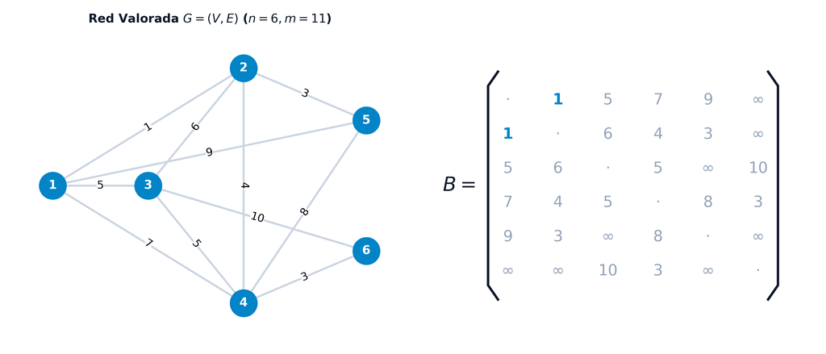

## Ejemplo Kruskal: Iteración 1 ($k=1, d=1$)

- **Selección de la arista de menor peso global**: $e_1 = \{1, 2\}$ con $d_{\{1,2\}} = 1$.
- **Consulta Union-Find**: $\text{Find}(1) \neq \text{Find}(2) \implies \{1\} \neq \{2\}$.
- **Actualización del árbol parcial**:
  - $T = \{\{1, 2\}\}$.
  - Subconjuntos disjuntos fusionados:
    $$\{1, 2\}, \, \{3\}, \, \{4\}, \, \{5\}, \, \{6\}$$

## Ejemplo Kruskal: Iteraciones 2 y 3 ($d=3$, empates)

- **Iteración $k=2$ ($d=3$)**:
  - Candidatas de peso 3: $\{2, 5\}$ y $\{4, 6\}$. Seleccionar $\{2, 5\}$.
  - $\text{Find}(2) \neq \text{Find}(5) \implies$ Aceptar $\{2, 5\}$.
  - $T = \{\{1, 2\}, \{2, 5\}\}$.
  - Subconjuntos: $\{1, 2, 5\}, \, \{3\}, \, \{4\}, \, \{6\}$.
- **Iteración $k=3$ ($d=3$)**:
  - Seleccionar la arista $\{4, 6\}$ de peso 3.
  - $\text{Find}(4) \neq \text{Find}(6) \implies$ Aceptar $\{4, 6\}$.
  - $T = \{\{1, 2\}, \{2, 5\}, \{4, 6\}\}$.
  - Subconjuntos: $\{1, 2, 5\}, \, \{3\}, \, \{4, 6\}$.

## Ejemplo Kruskal: Iteraciones 4 y 5 ($d=4, d=5$)

- **Iteración $k=4$ ($d=4$)**:
  - Arista $\{2, 4\}$ de peso 4.
  - $\text{Find}(2) \in \{1, 2, 5\}$ y $\text{Find}(4) \in \{4, 6\} \implies$ Componentes distintas, no forma ciclo.
  - $T = \{\{1, 2\}, \{2, 5\}, \{4, 6\}, \{2, 4\}\}$.
  - Subconjuntos: $\{1, 2, 4, 5, 6\}, \, \{3\}$.
- **Iteración $k=5$ ($d=5$, empate con $\{3,4\}$)**:
  - Arista $\{1, 3\}$ de peso 5.
  - $\text{Find}(1) \in \{1, 2, 4, 5, 6\}$ y $\text{Find}(3) \in \{3\} \implies$ Aceptar $\{1, 3\}$.
  - $T = \{\{1, 2\}, \{2, 5\}, \{4, 6\}, \{2, 4\}, \{1, 3\}\}$.
  - Subconjuntos: $\{1, 2, 3, 4, 5, 6\}$ (1 sola componente conexa).

## Ejemplo Kruskal: Conclusión y Peso Mínimo

- **Criterio de parada**: Se alcanzan exactamente $|T| = n - 1 = 5$ aristas en la solución parcial.
- **Cálculo del Peso Óptimo Acumulado**:
  $$\begin{aligned}
  d(T) &= d_{\{1,2\}} + d_{\{2,5\}} + d_{\{4,6\}} + d_{\{2,4\}} + d_{\{1,3\}} \\
  &= 1 + 3 + 3 + 4 + 5 = 16
  \end{aligned}$$
- **Árbol Soporte Mínimo resultado**: $H = (V, T)$ con $T = \{\{1, 2\}, \{2, 5\}, \{4, 6\}, \{2, 4\}, \{1, 3\}\}$.

## Ejemplo Kruskal: Solución Óptima Alternativa $T'$

- **Resolución de empate en $k=5$**: En la iteración 5 existía un empate entre $\{1, 3\}$ ($d=5$) y $\{3, 4\}$ ($d=5$).
- **Árbol Soporte Mínimo Alternativo $T'$**: Si se hubiese seleccionado $\{3, 4\}$ en lugar de $\{1, 3\}$:
  $$T' = \{\{1, 2\}, \{2, 5\}, \{4, 6\}, \{2, 4\}, \{3, 4\}\}$$
- **Peso del árbol alternativo**:
  $$d(T') = 1 + 3 + 3 + 4 + 5 = 16$$
- **Conclusión**: Cuando existen pesos duplicados, el árbol mínimo **puede no ser único**, aunque el peso óptimo $d(T)$ es siempre constante e invariable.

## Ejemplo Kruskal: Traza animada interactiva

[interactive chart not shown]

## Complejidad del Algoritmo de Kruskal

**Complejidad computacional de Kruskal**

- **Sin ordenación previa de aristas**: $O(m \log m) = O(m \log n)$.
- **Con aristas preordenadas**: $O(m \cdot \alpha(n))$ (casi lineal mediante compresión de caminos en Union-Find).

## Algoritmo de Prim (Jarník-Prim-Dijkstra)

**Historia y Filosofía del Algoritmo de Prim (1957)**

- Descubierto por Vojtěch Jarník (1930), redescubierto por Robert C. Prim (1957) y Edsger W. Dijkstra (1959).
- A diferencia de Kruskal (que gestiona un bosque inconexo), Prim hace crecer **una única arborescencia conexa continua** desde un nodo raíz inicial $v_1 \in V$.
- **Corte de la arborescencia**: Sea $P \subset V$ los nodos ya integrados ($P = \{v_1\}$ inicialmente) y $N = V \setminus P$ los nodos pendientes. En cada iteración se selecciona la arista de peso mínimo del corte $w(P)$.

## Esquema de Prim: Inicialización y Selección

Dada una red no dirigida valorada $G = (V, E, \mathbf{d})$ conexa con $n = |V| > 1$:

- **Paso 0 (Inicialización)**:
  - Seleccionar nodo raíz arbitrario $v_1 \in V$.
  - $P = \{v_1\}, N = V \setminus \{v_1\}, T = \emptyset, i = 1$.
- **Paso 1 (Arista Mínima del Corte $w(P)$)**:
  - Identificar $e^* = \{x^*, y^*\}$ con $x^* \in P, y^* \in N$ tal que:
    $$d(e^*) = \min \{d(e) : e = \{x, y\}, x \in P, y \in N\}$$
  - Actualizar: $P \leftarrow P \cup \{y^*\}, N \leftarrow N \setminus \{y^*\}, T \leftarrow T \cup \{e^*\}$.

## Esquema de Prim: Criterio de Parada

- **Paso 2 (Criterio de Parada e Incremento)**:
  - **Éxito**: Si $i = n - 1$, detener el procedimiento: el par $H = (V, T)$ es un **Árbol Soporte de Mínimo Peso (MST)**.
  - **Iteración continua**: Si $i < n - 1$, actualizar $i \leftarrow i + 1$ y regresar al Paso 1.

## Ejemplo Prim: Planteamiento y Raíz Inicial ($v_1 = 1$)

- **Misma red de referencia de 6 vértices**: $V = \{1, 2, 3, 4, 5, 6\}$ y 11 aristas.
- **Selección arbitraria del nodo raíz**: $v_1 = 1$.
- **Estado inicial ($i=1$)**:
  - Nodos integrados en la arborescencia: $P = \{1\}$.
  - Nodos pendientes de visitar: $N = \{2, 3, 4, 5, 6\}$.
  - Aristas del árbol parcial: $T = \emptyset$.

## Ejemplo Prim: Iteraciones 1 y 2 ($i=1, i=2$)

- **Iteración $i=1$**:
  - Corte $w(P)$ desde $P = \{1\}$ hacia $N$: $\{1, 2\}$ ($d=1$), $\{1, 3\}$ ($d=5$), $\{1, 4\}$ ($d=7$), $\{1, 5\}$ ($d=9$).
  - Arista de peso mínimo: $e^* = \{1, 2\}$ con $d=1$.
  - Actualización: $P = \{1, 2\}$, $N = \{3, 4, 5, 6\}$, $T = \{\{1, 2\}\}$.
- **Iteración $i=2$**:
  - Corte $w(P)$ desde $P = \{1, 2\}$ hacia $N$: $\{1, 3\}$ ($d=5$), $\{1, 4\}$ ($d=7$), $\{1, 5\}$ ($d=9$), $\{2, 3\}$ ($d=6$), $\{2, 4\}$ ($d=4$), $\{2, 5\}$ ($d=3$).
  - Arista de peso mínimo: $e^* = \{2, 5\}$ con $d=3$.
  - Actualización: $P = \{1, 2, 5\}$, $N = \{3, 4, 6\}$, $T = \{\{1, 2\}, \{2, 5\}\}$.

## Ejemplo Prim: Iteraciones 3 y 4 ($i=3, i=4$)

- **Iteración $i=3$**:
  - Corte $w(P)$ desde $P = \{1, 2, 5\}$ hacia $N = \{3, 4, 6\}$: $\{1, 3\}$ ($d=5$), $\{2, 4\}$ ($d=4$), $\{5, 4\}$ ($d=8$), etc.
  - Arista de peso mínimo: $e^* = \{2, 4\}$ con $d=4$.
  - Actualización: $P = \{1, 2, 4, 5\}$, $N = \{3, 6\}$, $T = \{\{1, 2\}, \{2, 5\}, \{2, 4\}\}$.
- **Iteración $i=4$**:
  - Corte $w(P)$ desde $P = \{1, 2, 4, 5\}$ hacia $N = \{3, 6\}$: $\{1, 3\}$ ($d=5$), $\{4, 3\}$ ($d=5$), $\{4, 6\}$ ($d=3$).
  - Arista de peso mínimo: $e^* = \{4, 6\}$ con $d=3$.
  - Actualización: $P = \{1, 2, 4, 5, 6\}$, $N = \{3\}$, $T = \{\{1, 2\}, \{2, 5\}, \{2, 4\}, \{4, 6\}\}$.

## Ejemplo Prim: Conclusión y Solución Alternativa $T'$

- **Cálculo del Peso Mínimo Óptimo**:
  $$\begin{aligned}
  d(T) &= d_{\{1,2\}} + d_{\{2,5\}} + d_{\{2,4\}} + d_{\{4,6\}} + d_{\{1,3\}} \\
  &= 1 + 3 + 4 + 3 + 5 = 16
  \end{aligned}$$
- **Solución Alternativa $T'$**: Elegir la arista $\{3, 4\}$ ($d=5$) en lugar de $\{1, 3\}$ en la iteración 5 produce el árbol alternativo $T' = \{\{1, 2\}, \{2, 5\}, \{2, 4\}, \{4, 6\}, \{3, 4\}\}$ con peso idéntico $d(T') = 16$.

## Ejemplo Prim: Traza animada interactiva

[interactive chart not shown]

## Complejidad del Algoritmo de Prim

**Complejidad computacional de Prim**

- **Implementación estándar con matriz de adyacencia**: $O(n^2)$.
- **Implementación con Heap binario**: $O(m \log n)$.
- **Implementación con Montículo de Fibonacci (Fib-Heap)**: **$O(m + n \log n)$** (óptimo para redes densas).

## Aprendizaje no supervisado y Medidas de Desemejanza

**Definición: Medida de desemejanza y distancia métrica**

Dada una colección de observaciones $x, y$, una **función de desemejanza** $\delta(x, y)$ cuantifica la divergencia entre ambas observando:

1. **Coincidencia nula**: $\delta(x, y) = 0 \iff x = y$.
2. **No negatividad**: $\delta(x, y) \ge 0, \forall x, y$.
3. **Simetría**: $\delta(x, y) = \delta(y, x)$.

Si satisface la **desigualdad triangular** $\delta(x, y) \le \delta(x, z) + \delta(y, z)$, es una **distancia métrica** (ej. $\|x - y\|_2$).

## Algoritmo de las k-Medias (K-Means)

**k-Medias (K-Means)**

- **Objetivo de optimización**: Minimiza la variabilidad intra-grupo ($WCSS$, *within-cluster sum of squares*):
  $$W(S, c) = \sum_{k=1}^K W(S_k) = \sum_{k=1}^K \sum_{x_i \in S_k} \|x_i - c_k\|^2$$
  donde $c_k$ representa el centroide (media aritmética) del clúster $S_k$.
- **Restricción geométrica**: Al basarse en centroides y regiones de Voronoi delimitadas por hiperplanos, **exige clústeres esféricos y convexos**.

## Clustering basado en Árbol Soporte de Mínimo Peso

**Clustering basado en MST (Single-Linkage)**

- **Modelado en red**: Modela la colección de $n$ observaciones como una red completa $G = (V, E, \delta)$ valorada por desemejanzas $\delta(x, y)$ y calcula su MST $T = (V, E')$.
- **Partición por corte**: Elimina las $K - 1$ aristas de mayor peso (mayor desemejanza) del MST.
- **Propiedad clave**: Particiona la red de forma determinista en $K$ componentes conexas de **geometría arbitraria y no lineal**.

## Ejemplo: Partición determinista por corte del MST

- **Procedimiento sobre $n = 9$ observaciones**:
  1. Construir el MST completo sobre la red de desemejanzas.
  2. Identificar y cortar las $K - 1 = 2$ aristas de mayor peso: $\{2, 4\}$ (longitud $8.5$) y $\{3, 7\}$ (longitud $7.0$).
  3. **Resultado**: Partición determinista en $K = 3$ clústeres disjuntos.

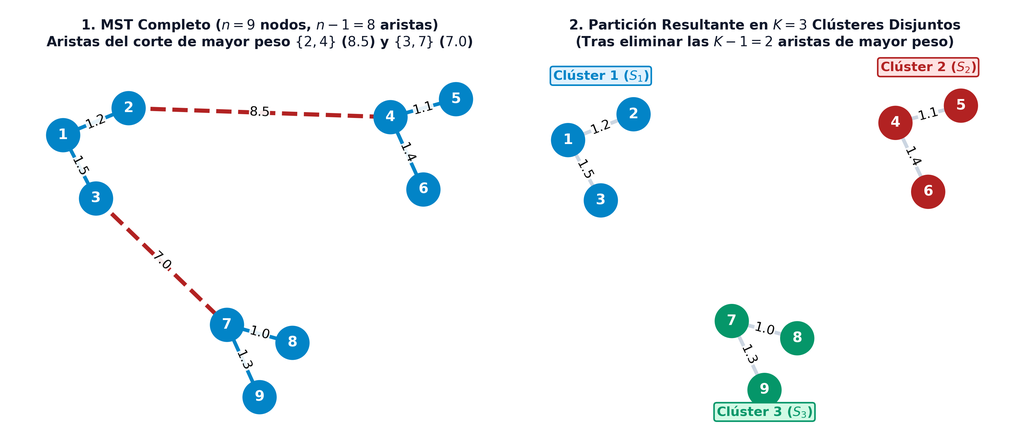

## Detección de estructuras con geometría no lineal

- **Estructuras complejas**: Anillos concéntricos (panel izquierdo) y dos lunas entrelazadas (panel derecho).
- **Superioridad del MST**: Mientras $k$-medias fracasa al trazar hiperplanos lineales rígidos, el MST elimina el puente de mayor desemejanza entre estructuras, capturando la topología no convexa exacta.

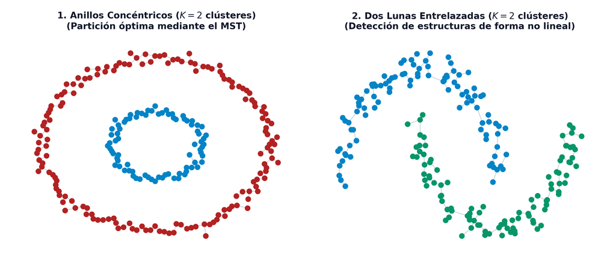

## Generalización: Funciones de calidad de partición F

- **Enfoque de Optimización Objetivo**: En lugar de cortar únicamente las $K - 1$ aristas de mayor peso, se define una **función de calidad o validez** $F : \mathcal{X}_\ell \to \mathbb{R}$ que evalúa la bondad de cada partición posible $C(V, E'')$.
- **Objetivo de Maximización**: Encontrar la partición de la red $C(V, E'') \in \mathcal{X}_\ell$ que maximiza el valor de la función de validez $F$.

## Maximización de F sobre el MST (Procedimiento Divisivo)

Dada una red de datos $G = (V, E, \delta)$ y una función de calidad $F$:

1. **Obtener el MST**: $T = \text{MST}(G) = (V, E', \delta)$.
2. **Inicializar aristas activas**: $E'' = E'$.
3. **Bucle de Selección Divisiva**: Para $i = 1, \dots, K - 1$:
   - Identificar $\{u, v\} = \arg\max_{e \in E''} F(C(V, E'' \setminus \{e\}))$.
   - Eliminar la arista seleccionada: $E'' \leftarrow E'' \setminus \{\{u, v\}\}$.
4. **Resultado de la partición**: Devolver la partición óptima $C(V, E'')$.

## Funciones de Calidad F: Separación y Variabilidad Intra-grupo

- **Criterio de mayor longitud (Separación)**: Suma de los costes/pesos de las aristas eliminadas del MST:
  $$F(X_1, \dots, X_\ell) = \sum_{i=1}^\ell \sum_{x_j \in X_i} x_j$$
- **Suma de cuadrados intra-grupo negativa ($-WCSS$)**: Minimización de la dispersión de las observaciones respecto a los centroides $\mu_i$:
  $$-WCSS(X_1, \dots, X_\ell) = -\sum_{i=1}^\ell \sum_{x_j \in X_i} \|x_j - \mu_i\|^2$$

## Funciones de Calidad F: Criterio de Información y Entropía

- **Criterio de Información / Entropía ($IC$)**: Balancea la homogeneidad de los subárboles con la proporción de observaciones:
  $$IC(X_1, \dots, X_\ell) = -d \sum_{i=1}^\ell \frac{n_i}{n} \log \frac{L_i}{n_i} - \sum_{i=1}^\ell \frac{n_i}{n} \log \frac{n_i}{n}$$
  donde $L_i$ representa la suma de los pesos de las aristas en el $i$-ésimo subárbol y $n_i = |X_i|$ es la cardinalidad de dicho clúster.
- **Criterio de dispersión de aristas**: Minimización de la desviación típica de las distancias de las aristas intra-clúster.

## Estrategias aglomerativas e inestabilidades prácticas

**Estrategia aglomerativa y corrección de inestabilidad**

- **Aproximación aglomerativa**: Comenzar con $E'' = \emptyset$ e ir añadiendo aristas del MST una a una que maximicen la función $F(C(V, E'' \cup \{\{u,v\}\}))$ hasta alcanzar $K$ componentes conexas.
- **Inconveniente práctico**: Puede formar grupos aislados de muy pocas observaciones en las iteraciones iniciales.
- **Solución**: Incorporar penalizaciones o restricciones basadas en el **índice de Gini** que favorezcan el equilibrio cuando exista una disparidad excesiva en la dimensión de los clústeres.